# Reproducible Research - Peer Assessment 1

Aim of this document is to answer questions on data about Personal Activity collected in Nov and Dec, 2012

## Preliminary: Loading and preprocessing data

Following chunk of code loads and preprocess data from file ‘activity.csv’

```r
if(!(file.exists("activity.csv") )) {
        filename <- "repdata-data-activity.zip"
        if(!file.exists(filename)) {
                fileURL <- "http://d396qusza40orc.cloudfront.net/repdata%2Fdata%2Factivity.zip"
                path <- getwd()
                dest <- paste(path,filename,sep="/")
                download.file(url=fileURL,destfile=dest,method="auto")
        }
        unzip(filename)
}

df <- read.csv("activity.csv",colClasses=c("numeric","character","numeric"))
```

## Question #1: What is mean total number of steps taken per day?

Answer is searched for performing the following steps:  
1. activity data is aggregated per day  
2. a histogram is created with data of steps per day  
3. mean and median of steps per day are calculated

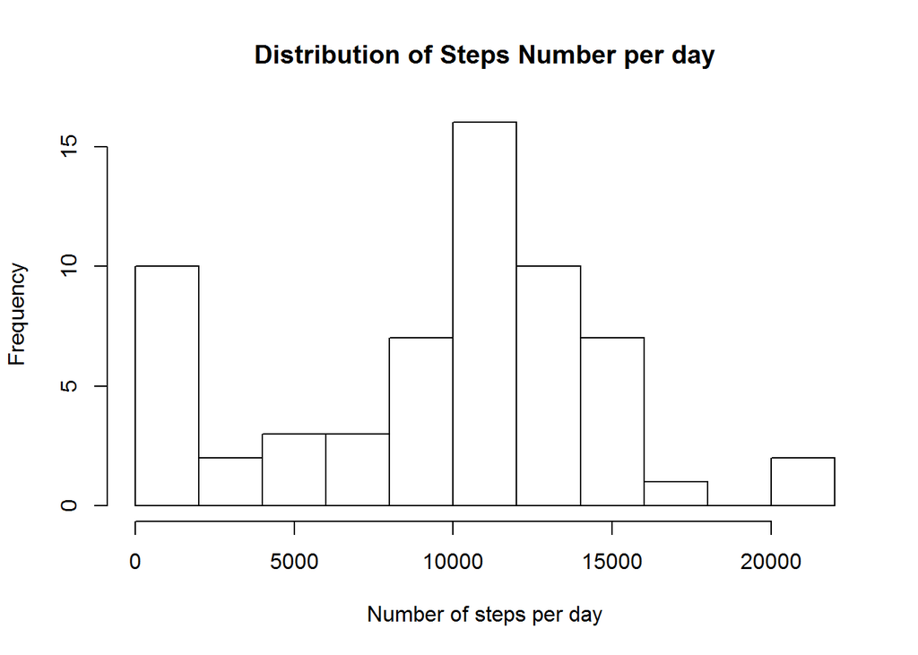

```r
  day_df <- data.frame(aggregate(df[,1],by=list(df$date),FUN=sum,na.rm=TRUE))
  day_df_names <- c("day","steps")
  day_df <- setNames(day_df,day_df_names)
  hist(day_df$steps,breaks=10,xlab="Number of steps per day",main="Distribution of Steps Number per day")
```

```r
  mean(day_df$steps,na.rm=TRUE)
```

```
## [1] 9354.23
```

```r
  median(day_df$steps,na.rm=TRUE)
```

```
## [1] 10395
```

## Question #2: What is the average daily activity pattern?

Answer is searched for performing the following steps:  
1. activity data is aggregated per 5-minute interval  
2. a plot type line is created to show the pattern

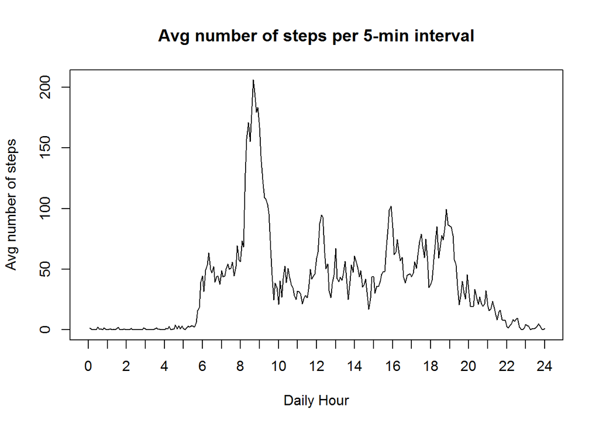

```r
  int_df <- data.frame(aggregate(df[,1],by=list(df$interval),FUN=mean,na.rm=TRUE))
  int_df_names <- c("interval","steps")
  int_df <- setNames(int_df,int_df_names)

  xmax <- nrow(int_df)
  xint <- c(0,xmax)

  ymax <- max(int_df$steps)
  yint <- c(0,ymax)

  xlab <- c(0:24)
  xlat <- seq(from=0,to=xmax,by=xmax/24)

  plot(1,type="n",xlab="Daily Hour",ylab="Avg number of steps",main="Avg number of steps per 5-min interval",xlim=xint,ylim=yint,xaxt="n")
  lines(int_df$steps)
  axis(1,labels=xlab,at=xlat)
```

## Question #3: Imputing missing values

Answer is searched for performing the following steps:  
1. creating a new data frame called “clean_df” where NA are replaced with means per interval 2. aggregating data of clean_df per day, and then creating histogram and calculating mean and median

```r
  null <- sum(is.na(df$steps))
  print(null)
```

```
## [1] 2304
```

```r
  library(dplyr)
```

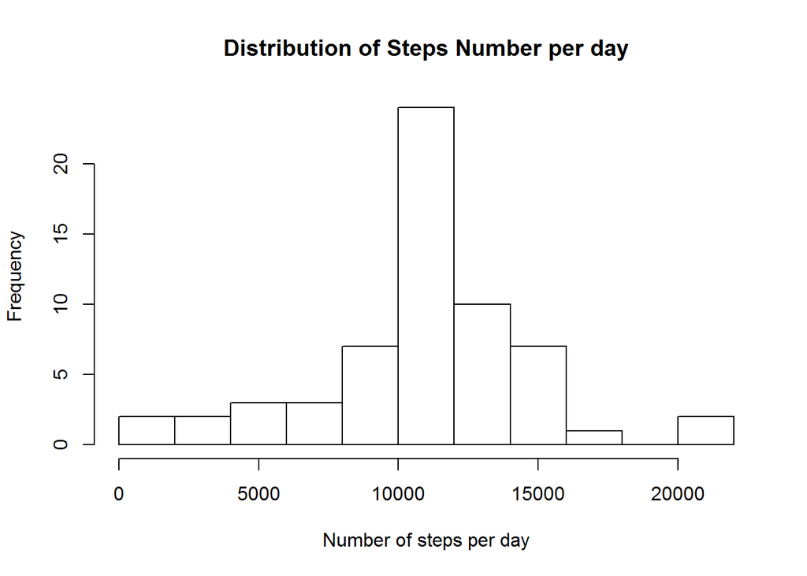

```r
  # replacement of NA with mean per interval: creation of clean_df
  new_df <- merge(df,int_df,by.x="interval",by.y="interval")
  clean_steps <- new_df$steps.x
  clean_steps[is.na(clean_steps)] <- 0
  rep_steps <- as.numeric(is.na(new_df$steps.x))*new_df$steps.y + as.numeric(complete.cases(new_df$steps.x))*clean_steps
  clean_df <- data.frame(rep_steps,new_df$date,new_df$interval)
  clean_df <- setNames(clean_df,c("steps","date","interval"))
  clean_df <- arrange(clean_df,date)

  #aggregation of clean_df per day, creation of histogram, calculation of mean and median
  new_day_df <- data.frame(aggregate(clean_df[,1],by=list(clean_df$date),FUN=sum,na.rm=TRUE))
  new_day_df_names <- c("day","steps")
  new_day_df <- setNames(new_day_df,new_day_df_names)
  hist(new_day_df$steps,breaks=10,xlab="Number of steps per day",main="Distribution of Steps Number per day")
```

```r
  mean(new_day_df$steps,na.rm=TRUE)
```

```
## [1] 10766.19
```

```r
  median(new_day_df$steps,na.rm=TRUE)
```

```
## [1] 10766.19
```

## Question #4: Patterns in weekdays and weekends

Answer is searched for performing the following steps:  
1. new factor variable called “weekfactor” is added to “clean_df” (“final_df” is created)  
2. “final_df” is aggregated by interval and weekfactor (mean of steps is calculated)  
3. plot is created

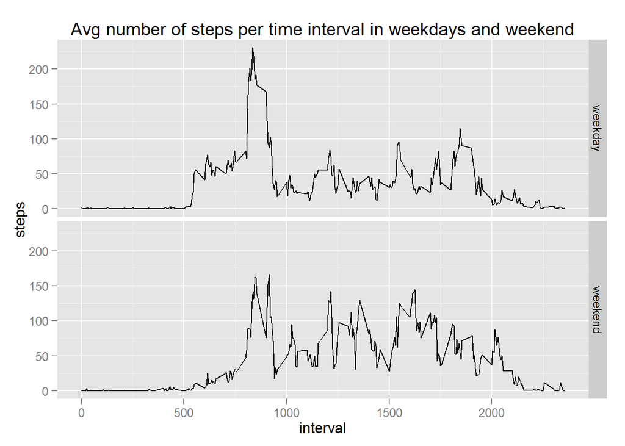

```r
  #creation of new variable
  final_df <- mutate(clean_df,weekfactor=ifelse(as.POSIXlt(df$date)$wday==0|as.POSIXlt(df$date)$wday==6,"weekend","weekday"))

  #aggregation of data by 5-min interval and weekfactor
  week_df <- data.frame(aggregate(final_df[,1],by=list(final_df$interval,final_df$weekfactor),FUN=mean,na.rm=TRUE))
  week_df_names <- c("interval","weekfactor","steps")
  week_df <- setNames(week_df,week_df_names)

  #creation of the plot
  library(ggplot2)

  g <- ggplot(week_df,aes(interval, steps))
  g <- g + geom_line() + facet_grid(weekfactor ~ .) + ggtitle("Avg number of steps per time interval in weekdays and weekend")
  print(g)
```